# Simulating the Upcoming CFB Season

Phil Henrickson & Trevor Cross

2022-08-12

# What is this?

Which teams are most likely to win their conference in 2022? Make the playoff? Win the national championship?

This notebook details results from simulating the 2022 college football season before any actual games are played. We use historical college football play by play and game data in order to develop a model for simulating upcoming games. All data is from collegefootballdata.com.

# 1 2022 Team Ratings

The following table displays each team’s **Rating**, which is estimated from their previous season’s Elo Rating, offensive efficiency, defensive efficiency, and a moving average of their composite recruiting score. These ratings are used to simulate the outcome of each game in an Elo framework, adjusting for home field advantage.

These ratings are **Week 0** ratings because they rely only on information from previous seasons. As the season progresses, these ratings will update for each team as we gain new information based on the results of games (with the exception of recruiting, which is computed at the yearly level).

| Rank | Conference | Team | Rating | Offense | Defense | Recruiting |
| --- | --- | --- | --- | --- | --- | --- |
| 1 | SEC | Georgia | 2005 | 0.209 | 0.277 | 309 |
| 2 | SEC | Alabama | 1969 | 0.199 | 0.165 | 319 |
| 3 | Big Ten | Ohio State | 1890 | 0.314 | 0.012 | 299 |
| 4 | Big Ten | Michigan | 1821 | 0.158 | 0.106 | 263 |
| 5 | ACC | Clemson | 1795 | -0.017 | 0.145 | 277 |
| 6 | FBS Independents | Notre Dame | 1792 | 0.039 | 0.122 | 267 |
| 7 | Big 12 | Oklahoma | 1787 | 0.156 | -0.028 | 267 |
| 8 | American Athletic | Cincinnati | 1779 | 0.078 | 0.127 | 189 |
| 9 | SEC | Texas A&M | 1769 | 0.024 | 0.126 | 301 |
| 10 | Big 12 | Oklahoma State | 1757 | 0.033 | 0.189 | 205 |

[output cut: 120 more lines]

Note: for teams that are new to FBS this year, we do not have information on their previous offensive/defensive efficiency, so their initial rating comes from an Elo model based only on their results against FBS teams in previous seasons.

## 1.1 Team Ratings by Conference

The following visualization shows the distribution of each team’s Week 0 rating by conference.

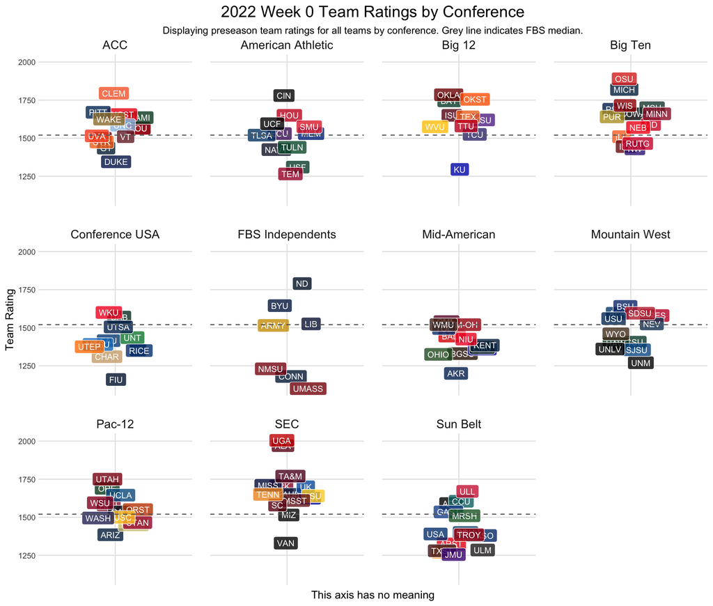

# 2 2022 Predictions

The following table shows each team’s strength of schedule (SOS), predicted record (for the regular season), probability of making a bowl, winning their conference championship, and making/winning in the playoff.

These results are based on simulating the 2022 season 1000 times and counting the number of simulations in which a team achieved each outcome.

| Conference | Team | SOS | Record | Bowl | Win_Conf | Playoff | Make_NC | Win_NC |
| --- | --- | --- | --- | --- | --- | --- | --- | --- |
| SEC | Georgia | 52 | 10.8 - 1.9 | 0.997 | 0.426 | 0.71 | 0.433 | 0.25 |
| SEC | Alabama | 39 | 10.3 - 2.2 | 0.996 | 0.327 | 0.608 | 0.367 | 0.21 |
| Big Ten | Ohio State | 24 | 9.8 - 2.6 | 0.985 | 0.275 | 0.43 | 0.222 | 0.122 |
| Big Ten | Michigan | 53 | 9.6 - 2.6 | 0.981 | 0.162 | 0.201 | 0.088 | 0.048 |
| Big 12 | Oklahoma | 37 | 8.8 - 3.4 | 0.933 | 0.283 | 0.223 | 0.101 | 0.044 |
| ACC | Clemson | 51 | 9.3 - 3.0 | 0.962 | 0.319 | 0.23 | 0.09 | 0.042 |
| Big 12 | Oklahoma State | 27 | 8.6 - 3.6 | 0.909 | 0.195 | 0.123 | 0.058 | 0.028 |
| Pac-12 | Utah | 50 | 8.7 - 3.6 | 0.923 | 0.275 | 0.137 | 0.06 | 0.025 |
| SEC | Texas A&M | 28 | 8.2 - 3.9 | 0.895 | 0.037 | 0.086 | 0.04 | 0.016 |
| Big 12 | Baylor | 41 | 8.1 - 4.0 | 0.872 | 0.159 | 0.09 | 0.043 | 0.014 |

[output cut: 121 more lines]

## 2.1 Conference Championship Predictions

These tables display the probability that each team will win their conference or finish as the runner-up.

### 2.1.1 SEC

| 2022 Conference Championship Probabilties Season | 2022 Conference Championship Probabilties Conference | 2022 Conference Championship Probabilties Division | 2022 Conference Championship Probabilties Team | 2022 Conference Championship Probabilties Champion | 2022 Conference Championship Probabilties Runner-Up |
| --- | --- | --- | --- | --- | --- |
| 2022 | SEC | East | Georgia | 0.426 | 0.311 |
| 2022 | SEC | East | Kentucky | 0.047 | 0.071 |
| 2022 | SEC | East | Tennessee | 0.027 | 0.037 |
| 2022 | SEC | East | South Carolina | 0.012 | 0.026 |
| 2022 | SEC | East | Florida | 0.011 | 0.026 |
| 2022 | SEC | East | Missouri | 0.001 | 0.005 |
| 2022 | SEC | East | Vanderbilt | 0.000 | 0.000 |
| 2022 | SEC | West | Alabama | 0.327 | 0.288 |
| 2022 | SEC | West | Ole Miss | 0.043 | 0.072 |
| 2022 | SEC | West | Texas A&M | 0.037 | 0.046 |
| 2022 | SEC | West | Arkansas | 0.029 | 0.048 |
| 2022 | SEC | West | Auburn | 0.018 | 0.036 |
| 2022 | SEC | West | LSU | 0.011 | 0.022 |
| 2022 | SEC | West | Mississippi State | 0.011 | 0.012 |

### 2.1.2 Big Ten

| 2022 Conference Championship Probabilties Season | 2022 Conference Championship Probabilties Conference | 2022 Conference Championship Probabilties Division | 2022 Conference Championship Probabilties Team | 2022 Conference Championship Probabilties Champion | 2022 Conference Championship Probabilties Runner-Up |
| --- | --- | --- | --- | --- | --- |
| 2022 | Big Ten | East | Ohio State | 0.275 | 0.100 |
| 2022 | Big Ten | East | Michigan | 0.162 | 0.082 |
| 2022 | Big Ten | East | Penn State | 0.081 | 0.082 |
| 2022 | Big Ten | East | Michigan State | 0.078 | 0.072 |
| 2022 | Big Ten | East | Maryland | 0.038 | 0.020 |
| 2022 | Big Ten | East | Indiana | 0.002 | 0.005 |
| 2022 | Big Ten | East | Rutgers | 0.001 | 0.002 |
| 2022 | Big Ten | West | Iowa | 0.095 | 0.163 |
| 2022 | Big Ten | West | Wisconsin | 0.089 | 0.136 |
| 2022 | Big Ten | West | Minnesota | 0.074 | 0.108 |
| 2022 | Big Ten | West | Purdue | 0.070 | 0.122 |
| 2022 | Big Ten | West | Nebraska | 0.022 | 0.063 |
| 2022 | Big Ten | West | Illinois | 0.012 | 0.032 |
| 2022 | Big Ten | West | Northwestern | 0.001 | 0.013 |

### 2.1.3 Big 12

| 2022 Conference Championship Probabilties Season | 2022 Conference Championship Probabilties Conference | 2022 Conference Championship Probabilties Division | 2022 Conference Championship Probabilties Team | 2022 Conference Championship Probabilties Champion | 2022 Conference Championship Probabilties Runner-Up |
| --- | --- | --- | --- | --- | --- |
| 2022 | Big 12 |  | Oklahoma | 0.283 | 0.202 |
| 2022 | Big 12 |  | Oklahoma State | 0.195 | 0.166 |
| 2022 | Big 12 |  | Baylor | 0.159 | 0.180 |
| 2022 | Big 12 |  | Iowa State | 0.113 | 0.117 |
| 2022 | Big 12 |  | Texas | 0.066 | 0.094 |
| 2022 | Big 12 |  | Kansas State | 0.060 | 0.076 |
| 2022 | Big 12 |  | Texas Tech | 0.048 | 0.055 |
| 2022 | Big 12 |  | West Virginia | 0.044 | 0.065 |
| 2022 | Big 12 |  | TCU | 0.032 | 0.044 |
| 2022 | Big 12 |  | Kansas | 0.000 | 0.001 |

### 2.1.4 ACC

| 2022 Conference Championship Probabilties Season | 2022 Conference Championship Probabilties Conference | 2022 Conference Championship Probabilties Division | 2022 Conference Championship Probabilties Team | 2022 Conference Championship Probabilties Champion | 2022 Conference Championship Probabilties Runner-Up |
| --- | --- | --- | --- | --- | --- |
| 2022 | ACC | Atlantic | Clemson | 0.319 | 0.164 |
| 2022 | ACC | Atlantic | NC State | 0.090 | 0.056 |
| 2022 | ACC | Atlantic | Wake Forest | 0.080 | 0.076 |
| 2022 | ACC | Atlantic | Florida State | 0.051 | 0.045 |
| 2022 | ACC | Atlantic | Louisville | 0.034 | 0.031 |
| 2022 | ACC | Atlantic | Boston College | 0.016 | 0.017 |
| 2022 | ACC | Atlantic | Syracuse | 0.010 | 0.011 |
| 2022 | ACC | Coastal | Pittsburgh | 0.133 | 0.154 |
| 2022 | ACC | Coastal | Miami | 0.118 | 0.140 |
| 2022 | ACC | Coastal | North Carolina | 0.058 | 0.111 |
| 2022 | ACC | Coastal | Virginia | 0.040 | 0.085 |
| 2022 | ACC | Coastal | Virginia Tech | 0.036 | 0.068 |
| 2022 | ACC | Coastal | Georgia Tech | 0.011 | 0.029 |
| 2022 | ACC | Coastal | Duke | 0.004 | 0.013 |

### 2.1.5 Pac-12

| 2022 Conference Championship Probabilties Season | 2022 Conference Championship Probabilties Conference | 2022 Conference Championship Probabilties Division | 2022 Conference Championship Probabilties Team | 2022 Conference Championship Probabilties Champion | 2022 Conference Championship Probabilties Runner-Up |
| --- | --- | --- | --- | --- | --- |
| 2022 | Pac-12 |  | Utah | 0.275 | 0.132 |
| 2022 | Pac-12 |  | Oregon | 0.178 | 0.176 |
| 2022 | Pac-12 |  | UCLA | 0.125 | 0.145 |
| 2022 | Pac-12 |  | Washington State | 0.103 | 0.110 |
| 2022 | Pac-12 |  | Arizona State | 0.095 | 0.108 |
| 2022 | Pac-12 |  | Oregon State | 0.064 | 0.085 |
| 2022 | Pac-12 |  | California | 0.058 | 0.086 |
| 2022 | Pac-12 |  | USC | 0.033 | 0.040 |
| 2022 | Pac-12 |  | Colorado | 0.023 | 0.028 |
| 2022 | Pac-12 |  | Washington | 0.022 | 0.048 |
| 2022 | Pac-12 |  | Stanford | 0.017 | 0.025 |
| 2022 | Pac-12 |  | Arizona | 0.007 | 0.017 |

### 2.1.6 American Athletic

| 2022 Conference Championship Probabilties Season | 2022 Conference Championship Probabilties Conference | 2022 Conference Championship Probabilties Division | 2022 Conference Championship Probabilties Team | 2022 Conference Championship Probabilties Champion | 2022 Conference Championship Probabilties Runner-Up |
| --- | --- | --- | --- | --- | --- |
| 2022 | American Athletic |  | Cincinnati | 0.434 | 0.195 |
| 2022 | American Athletic |  | Houston | 0.134 | 0.195 |
| 2022 | American Athletic |  | UCF | 0.103 | 0.139 |
| 2022 | American Athletic |  | SMU | 0.087 | 0.098 |
| 2022 | American Athletic |  | East Carolina | 0.072 | 0.101 |
| 2022 | American Athletic |  | Memphis | 0.064 | 0.100 |
| 2022 | American Athletic |  | Tulsa | 0.062 | 0.091 |
| 2022 | American Athletic |  | Tulane | 0.025 | 0.032 |
| 2022 | American Athletic |  | Navy | 0.011 | 0.025 |
| 2022 | American Athletic |  | Temple | 0.006 | 0.011 |
| 2022 | American Athletic |  | South Florida | 0.002 | 0.013 |

### 2.1.7 Sun Belt

| 2022 Conference Championship Probabilties Season | 2022 Conference Championship Probabilties Conference | 2022 Conference Championship Probabilties Division | 2022 Conference Championship Probabilties Team | 2022 Conference Championship Probabilties Champion | 2022 Conference Championship Probabilties Runner-Up |
| --- | --- | --- | --- | --- | --- |
| 2022 | Sun Belt | East | Coastal Carolina | 0.198 | 0.188 |
| 2022 | Sun Belt | East | Georgia State | 0.096 | 0.077 |
| 2022 | Sun Belt | East | Marshall | 0.096 | 0.075 |
| 2022 | Sun Belt | East | Appalachian State | 0.095 | 0.088 |
| 2022 | Sun Belt | East | Old Dominion | 0.022 | 0.021 |
| 2022 | Sun Belt | East | Georgia Southern | 0.015 | 0.019 |
| 2022 | Sun Belt | East | James Madison | 0.004 | 0.006 |
| 2022 | Sun Belt | West | Louisiana | 0.406 | 0.361 |
| 2022 | Sun Belt | West | South Alabama | 0.019 | 0.047 |
| 2022 | Sun Belt | West | Troy | 0.017 | 0.036 |
| 2022 | Sun Belt | West | Texas State | 0.013 | 0.028 |
| 2022 | Sun Belt | West | Louisiana Monroe | 0.007 | 0.015 |
| 2022 | Sun Belt | West | Arkansas State | 0.006 | 0.022 |
| 2022 | Sun Belt | West | Southern Mississippi | 0.006 | 0.017 |

### 2.1.8 Mountain West

| 2022 Conference Championship Probabilties Season | 2022 Conference Championship Probabilties Conference | 2022 Conference Championship Probabilties Division | 2022 Conference Championship Probabilties Team | 2022 Conference Championship Probabilties Champion | 2022 Conference Championship Probabilties Runner-Up |
| --- | --- | --- | --- | --- | --- |
| 2022 | Mountain West | Mountain | Boise State | 0.185 | 0.130 |
| 2022 | Mountain West | Mountain | Air Force | 0.142 | 0.116 |
| 2022 | Mountain West | Mountain | Utah State | 0.125 | 0.107 |
| 2022 | Mountain West | Mountain | Wyoming | 0.059 | 0.067 |
| 2022 | Mountain West | Mountain | Colorado State | 0.019 | 0.029 |
| 2022 | Mountain West | Mountain | New Mexico | 0.004 | 0.017 |
| 2022 | Mountain West | West | San Diego State | 0.166 | 0.168 |
| 2022 | Mountain West | West | Nevada | 0.135 | 0.175 |
| 2022 | Mountain West | West | Fresno State | 0.114 | 0.100 |
| 2022 | Mountain West | West | San José State | 0.022 | 0.055 |
| 2022 | Mountain West | West | Hawai'i | 0.020 | 0.024 |
| 2022 | Mountain West | West | UNLV | 0.009 | 0.012 |

### 2.1.9 Mid-American

| 2022 Conference Championship Probabilties Season | 2022 Conference Championship Probabilties Conference | 2022 Conference Championship Probabilties Division | 2022 Conference Championship Probabilties Team | 2022 Conference Championship Probabilties Champion | 2022 Conference Championship Probabilties Runner-Up |
| --- | --- | --- | --- | --- | --- |
| 2022 | Mid-American | East | Miami (OH) | 0.202 | 0.215 |
| 2022 | Mid-American | East | Buffalo | 0.058 | 0.122 |
| 2022 | Mid-American | East | Kent State | 0.049 | 0.075 |
| 2022 | Mid-American | East | Bowling Green | 0.043 | 0.107 |
| 2022 | Mid-American | East | Ohio | 0.035 | 0.071 |
| 2022 | Mid-American | East | Akron | 0.010 | 0.013 |
| 2022 | Mid-American | West | Central Michigan | 0.183 | 0.123 |
| 2022 | Mid-American | West | Western Michigan | 0.166 | 0.106 |
| 2022 | Mid-American | West | Toledo | 0.124 | 0.070 |
| 2022 | Mid-American | West | Northern Illinois | 0.054 | 0.032 |
| 2022 | Mid-American | West | Ball State | 0.051 | 0.040 |
| 2022 | Mid-American | West | Eastern Michigan | 0.025 | 0.026 |

### 2.1.10 Conference USA

| 2022 Conference Championship Probabilties Season | 2022 Conference Championship Probabilties Conference | 2022 Conference Championship Probabilties Division | 2022 Conference Championship Probabilties Team | 2022 Conference Championship Probabilties Champion | 2022 Conference Championship Probabilties Runner-Up |
| --- | --- | --- | --- | --- | --- |
| 2022 | Conference USA |  | Western Kentucky | 0.283 | 0.170 |
| 2022 | Conference USA |  | UAB | 0.181 | 0.139 |
| 2022 | Conference USA |  | UT San Antonio | 0.148 | 0.146 |
| 2022 | Conference USA |  | Florida Atlantic | 0.085 | 0.108 |
| 2022 | Conference USA |  | North Texas | 0.080 | 0.075 |
| 2022 | Conference USA |  | Middle Tennessee | 0.067 | 0.086 |
| 2022 | Conference USA |  | UTEP | 0.053 | 0.097 |
| 2022 | Conference USA |  | Rice | 0.038 | 0.047 |
| 2022 | Conference USA |  | Louisiana Tech | 0.035 | 0.065 |
| 2022 | Conference USA |  | Charlotte | 0.028 | 0.056 |
| 2022 | Conference USA |  | Florida International | 0.002 | 0.011 |